# Homework 4

James Livingstone

November 8, 2022

# 1.

```r
hprices %>%
  select(LotArea, Age, AgeRemod, BsmtSF, FirstFlrSF, SecondFlrSF, Baths, BedroomAbvGr, Fireplaces, GarageCars, GarageArea, SalePrice) %>%
  descr(stats = "common", transpose = T)
```

```
## Descriptive Statistics
## hprices
## N: 172
##
##                           Mean    Std.Dev        Min      Median         Max   N.Valid   Pct.Valid
## ------------------ ----------- ---------- ---------- ----------- ----------- --------- -----------
##                Age       38.19      28.11       0.00       38.50      135.00    172.00      100.00
##           AgeRemod       24.42      20.31       0.00       15.50       60.00    172.00      100.00
##              Baths        1.73       0.63       0.00        2.00        3.50    172.00      100.00
##       BedroomAbvGr        2.89       0.81       0.00        3.00        5.00    172.00      100.00
##             BsmtSF     1056.95     413.61       0.00     1019.00     2330.00    172.00      100.00
##         Fireplaces        0.59       0.68       0.00        0.00        2.00    172.00      100.00
##         FirstFlrSF     1167.46     382.14     372.00     1065.00     2364.00    172.00      100.00
##         GarageArea      451.92     188.43       0.00      480.00      923.00    172.00      100.00
##         GarageCars        1.69       0.71       0.00        2.00        3.00    172.00      100.00
##            LotArea    10254.01    6412.94    1491.00     9479.00    57200.00    172.00      100.00
##          SalePrice   179167.00   79966.10   55000.00   156450.00   611657.00    172.00      100.00
##        SecondFlrSF      316.34     431.76       0.00        0.00     1589.00    172.00      100.00
```

```r
hprices %>%
  select(BldgType, CentralAir, Bsmt, SecondFlr ) %>%
  freq(stats = "common", transpose = T)
```

```
## Frequencies
## hprices$BldgType
## Type: Character
##
##                   Freq   % Valid   % Valid Cum.   % Total   % Total Cum.
## --------------- ------ --------- -------------- --------- --------------
##          Duplex      7      4.07           4.07      4.07           4.07
##       OneFamily    140     81.40          85.47     81.40          85.47
##       Townhouse     25     14.53         100.00     14.53         100.00
##            <NA>      0                               0.00         100.00
##           Total    172    100.00         100.00    100.00         100.00
##
## hprices$CentralAir
## Type: Character
##
##               Freq   % Valid   % Valid Cum.   % Total   % Total Cum.
## ----------- ------ --------- -------------- --------- --------------
##           N     10      5.81           5.81      5.81           5.81
##           Y    162     94.19         100.00     94.19         100.00
##        <NA>      0                               0.00         100.00
##       Total    172    100.00         100.00    100.00         100.00
##
## hprices$Bsmt
## Type: Character
##
##               Freq   % Valid   % Valid Cum.   % Total   % Total Cum.
## ----------- ------ --------- -------------- --------- --------------
##           N      5      2.91           2.91      2.91           2.91
##           Y    167     97.09         100.00     97.09         100.00
##        <NA>      0                               0.00         100.00
##       Total    172    100.00         100.00    100.00         100.00
##
## hprices$SecondFlr
## Type: Character
##
##               Freq   % Valid   % Valid Cum.   % Total   % Total Cum.
## ----------- ------ --------- -------------- --------- --------------
##           N    105     61.05          61.05     61.05          61.05
##           Y     67     38.95         100.00     38.95         100.00
##        <NA>      0                               0.00         100.00
##       Total    172    100.00         100.00    100.00         100.00
```

# 2.

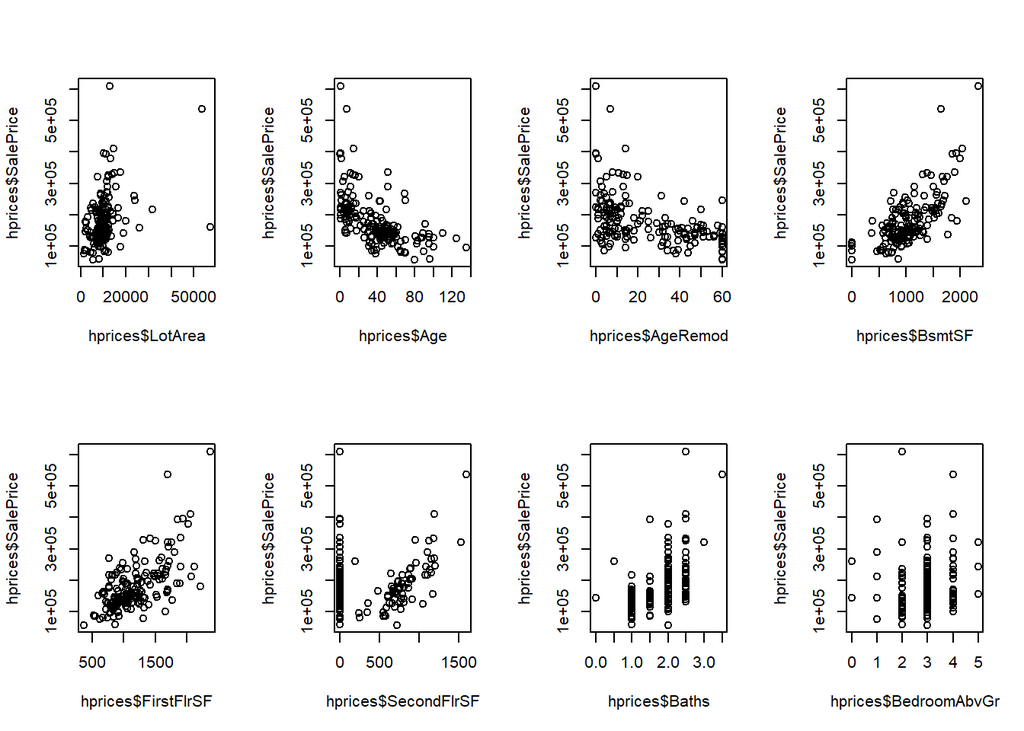

```r
par(mfrow = c(2,4))
plot(hprices$LotArea, hprices$SalePrice)
plot(hprices$Age, hprices$SalePrice)
plot(hprices$AgeRemod, hprices$SalePrice)
plot(hprices$BsmtSF, hprices$SalePrice)
plot(hprices$FirstFlrSF, hprices$SalePrice)
plot(hprices$SecondFlrSF, hprices$SalePrice)
plot(hprices$Baths, hprices$SalePrice)
plot(hprices$BedroomAbvGr, hprices$SalePrice)
```

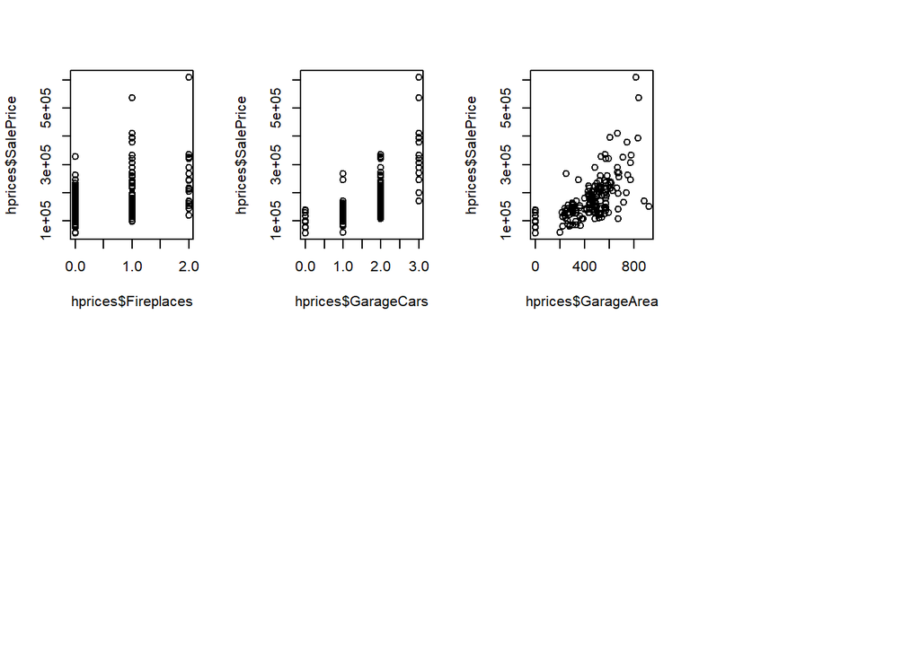

```r
plot(hprices$Fireplaces, hprices$SalePrice)
plot(hprices$GarageCars, hprices$SalePrice)
plot(hprices$GarageArea, hprices$SalePrice)
```

# 3.

```r
main_model = lm(SalePrice ~ LotArea + Age + AgeRemod + BsmtSF + FirstFlrSF + SecondFlrSF + Baths + BedroomAbvGr + Fireplaces + GarageCars + GarageArea + BldgType + CentralAir + Bsmt + SecondFlr, data = hprices)
vif(main_model)
```

```
##                   GVIF Df GVIF^(1/(2*Df))
## LotArea       1.533797  1        1.238465
## Age           2.788733  1        1.669950
## AgeRemod      1.808549  1        1.344823
## BsmtSF        6.568544  1        2.562917
## FirstFlrSF    6.432114  1        2.536161
## SecondFlrSF  11.207613  1        3.347777
## Baths         3.958069  1        1.989490
## BedroomAbvGr  2.024199  1        1.422744
## Fireplaces    1.524304  1        1.234627
## GarageCars    6.597693  1        2.568598
## GarageArea    6.115027  1        2.472858
## BldgType      1.908723  2        1.175400
## CentralAir    1.525531  1        1.235124
## Bsmt          2.086172  1        1.444359
## SecondFlr     9.003253  1        3.000542
```

GarageCars, GarageArea, BsmtSF, FirstFlrSF, SecondFlrSF, SecondFlr appear to be collinear due to their GVIF values being more than 2.23.

#4.

```r
hprices = hprices%>%
      mutate(TotalSF = BsmtSF + FirstFlrSF + SecondFlrSF)

main_model = lm(SalePrice ~ LotArea + Age + AgeRemod + TotalSF + Baths + BedroomAbvGr + Fireplaces + GarageCars + GarageArea + BldgType + CentralAir + Bsmt + SecondFlr, data = hprices)

vif(main_model)
```

```
##                  GVIF Df GVIF^(1/(2*Df))
## LotArea      1.401332  1        1.183779
## Age          2.509737  1        1.584215
## AgeRemod     1.777562  1        1.333252
## TotalSF      2.999171  1        1.731811
## Baths        3.807308  1        1.951232
## BedroomAbvGr 1.748336  1        1.322247
## Fireplaces   1.461854  1        1.209072
## GarageCars   6.504506  1        2.550393
## GarageArea   5.992337  1        2.447925
## BldgType     1.809016  2        1.159740
## CentralAir   1.492993  1        1.221881
## Bsmt         1.369121  1        1.170094
## SecondFlr    1.882279  1        1.371962
```

Yes, there is still evidence of collinearity with GarageCars and GarageArea both having GVIFs above 2.23. This makes sense because the more garage area you have available, the more cars can fit in the garage.

# 5.

```r
main_model = lm(SalePrice ~ LotArea + Age + AgeRemod + TotalSF + Baths + BedroomAbvGr + Fireplaces + GarageArea + BldgType + CentralAir + Bsmt + SecondFlr, data = hprices) #removed GarageCars

vif(main_model)
```

```
##                  GVIF Df GVIF^(1/(2*Df))
## LotArea      1.401291  1        1.183761
## Age          2.465835  1        1.570298
## AgeRemod     1.777312  1        1.333159
## TotalSF      2.998638  1        1.731658
## Baths        3.719589  1        1.928624
## BedroomAbvGr 1.745840  1        1.321302
## Fireplaces   1.449112  1        1.203791
## GarageArea   1.715260  1        1.309679
## BldgType     1.808457  2        1.159650
## CentralAir   1.491726  1        1.221363
## Bsmt         1.353542  1        1.163418
## SecondFlr    1.881770  1        1.371776
```

#6

```r
full_model =  lm(SalePrice ~ LotArea + Age + AgeRemod + TotalSF + Baths + BedroomAbvGr + Fireplaces + GarageArea + BldgType + CentralAir + Bsmt + SecondFlr, data = hprices)
intercept_model = lm(SalePrice ~ 1, data = hprices)
step(intercept_model, formula(full_model), trace = 0)
```

```
##
## Call:
## lm(formula = SalePrice ~ TotalSF + Age + GarageArea + AgeRemod +
##     LotArea + BedroomAbvGr + SecondFlr + Bsmt + BldgType, data = hprices)
##
## Coefficients:
##       (Intercept)            TotalSF                Age         GarageArea
##         39053.091             70.996           -479.276             51.680
##          AgeRemod            LotArea       BedroomAbvGr         SecondFlrY
##          -486.947              1.556         -15667.260          14155.610
##             BsmtY  BldgTypeOneFamily  BldgTypeTownhouse
##        -40051.241          31642.000          24101.074
```

#7

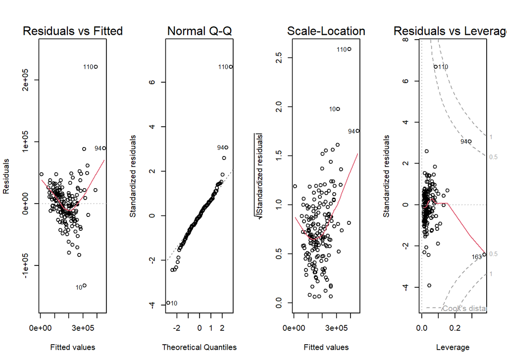

```r
par(mfrow = c(1, 4))
residual_model =  lm(SalePrice ~ LotArea + Age + AgeRemod + TotalSF + BedroomAbvGr + GarageArea, data = hprices)
plot(residual_model)
```

The plot Residuals vs Fitted is non-linear. The plot Normal Q-Q is mostly normal. The Scale-Location has heteroscedasticity. Residuals vs Leverage has an influential point.

#8

```r
transformed_model =  lm(log(SalePrice) ~ LotArea + Age + AgeRemod + TotalSF + Baths + BedroomAbvGr + Fireplaces + GarageArea + BldgType + CentralAir + Bsmt + SecondFlr, data = hprices)
transformed_intercept_model = lm(log(SalePrice) ~ 1, data = hprices)
step(transformed_intercept_model, formula(transformed_model), trace = 0)
```

```
##
## Call:
## lm(formula = log(SalePrice) ~ TotalSF + Age + GarageArea + AgeRemod +
##     LotArea + Fireplaces + BldgType + SecondFlr + BedroomAbvGr +
##     CentralAir, data = hprices)
##
## Coefficients:
##       (Intercept)            TotalSF                Age         GarageArea
##         1.119e+01          2.865e-04         -3.195e-03          3.620e-04
##          AgeRemod            LotArea         Fireplaces  BldgTypeOneFamily
##        -2.624e-03          4.650e-06          3.692e-02          7.470e-02
## BldgTypeTownhouse         SecondFlrY       BedroomAbvGr        CentralAirY
##        -7.754e-03          5.962e-02         -3.794e-02          8.056e-02
```

#9

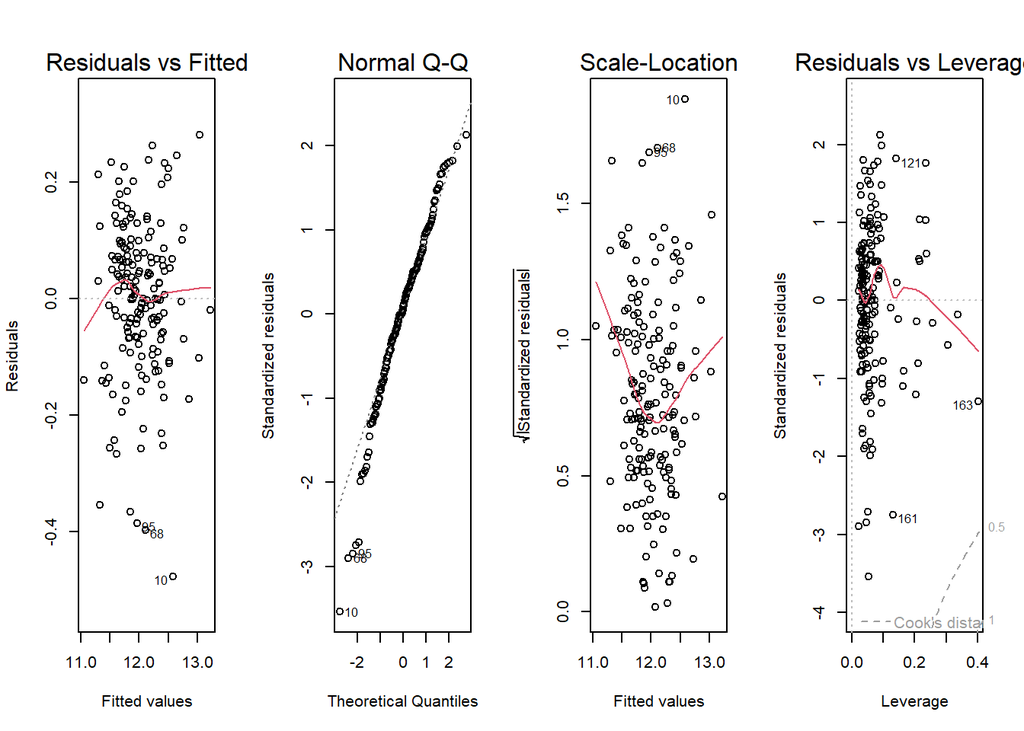

```r
par(mfrow = c(1,4))
residual_model2 = lm(log(SalePrice) ~ TotalSF + Age + GarageArea + AgeRemod + LotArea + Fireplaces + BldgType + SecondFlr + BedroomAbvGr + CentralAir, data = hprices)
plot(residual_model2)
```

The plot Residuals vs Fitted is linear. The plot Normal Q-Q is non-normal. The Scale-Location has no heteroscedasticity. Residuals vs Leverage has no influential points.

This model fits better than the model in #6 because even though its Q-Q plot is non-normal, the other plots look good with linearity, no heteroscedasticity, and no influential points in contrast to the plots in the model in #6.

#10

```r
prediction = predict(residual_model2, newdata = data.frame(BldgType = "OneFamily", Age = 38, AgeRemod = 24, BedroomAbvGr = 3, TotalSF = 2224, GarageArea = 452, CentralAir = "Y", Fireplaces = 1, LotArea = 10254, SecondFlr = "N"), interval = "prediction", level = 0.95)
exp(prediction)
```

```
##      fit      lwr      upr
## 1 152286 115554.7 200692.9
```

The predicted sales price of the home in Ohio in 2010 is 152286 dollars.

#11

We are 95% confident that a one-family home, 38 years old, renovated 24 years ago, with 3 above ground bedrooms, a total square footage of 2224, a garage area of 452, central air, 1 fire place, a lot area of 10254, and no second floor will have a prediction sale price of between 115554.7 and 200692.9 dollars.